# pro1

Yiming Shi

9/13/2018

### Step.0 Loading Packages

```r
library(tidyverse)
library(tidytext)
library(DT)
library(scales)
library(wordcloud2)
library(gridExtra)
library(ngram)
library(shiny)
library(igraph)
library(ggplot2)
library(dplyr)
library(tm)
library(topicmodels)
library(reshape2)
```

### Step.1 Loading, merging datasets

First, I loaded “processed_moments.csv” from the Fall2018-Proj1-Yiming001/output folder named hm_data, and also loaded the “demographic.csv” named “demo_data”, these two files include variables I need. Then, I combined these two dataset into one dataset in order to better use the infomation in these two dataset.

### Step.2 Create a visualization of the most common words

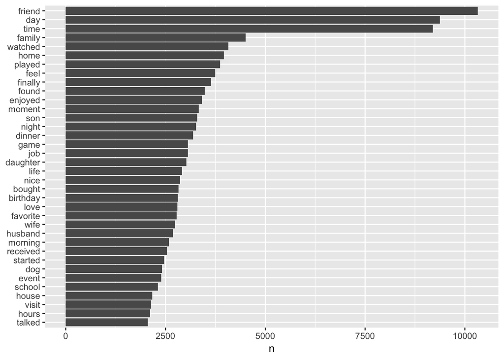

### Step.3 Split dataset

I am just really interested in whether there exist any differences in happy moments between countries. So in the first step, I have to figure out how to split the dataset depending on country, I used ggplot to see the distribution of country. And I found there exist two outliers (USA and IND) and other countries almost lie on the horizontal line. Then, I splited the dataset into three subsets(US, IND, OTHERS), so that the first one only contains the all information about USA country, the second one only contains the all information about IND country, and the third one contains the all information about other countries except USA and IND. I can start our analysis by using these three datasets!

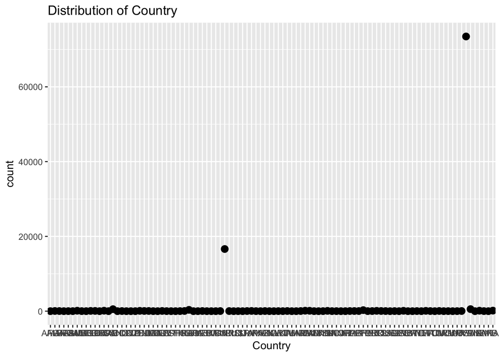

From the graph, I can see there are two outliers, now I need to see which two countries are. From the datatable, I can see top two countries are USA and IND (Frequency: larger than 10000), others are less than 600, so small, indicating I can split into three country groups.

|  | Var1 | Freq |
| --- | --- | --- |
| 94 | USA | 73475 |
| 40 | IND | 16629 |
| 95 | VEN | 546 |
| 15 | CAN | 531 |
| 32 | GBR | 355 |
| 71 | PHL | 276 |
| 97 | VNM | 125 |
| 13 | BRA | 123 |
| 58 | MEX | 123 |
| 7 | AUS | 117 |

[output cut: 89 more lines]

### Step.3 Word Cloud for three country groups

Let’s look at the wordcloud first! The wordclouds show that in each country group, which word appears most frequently, the larger the word is. Every wordcloud is followed by the corresponding word frequency plot. I can see the first three most common words are “friend”, “time”, “day”, matching the top three most common words in step 2 (whole dataset). But I also found there are special frequently words for different groups. For USA, like “played”, “dinner”, “game”. For IND, like “birthday”, “enjoy”, “life”.

[interactive chart not shown]

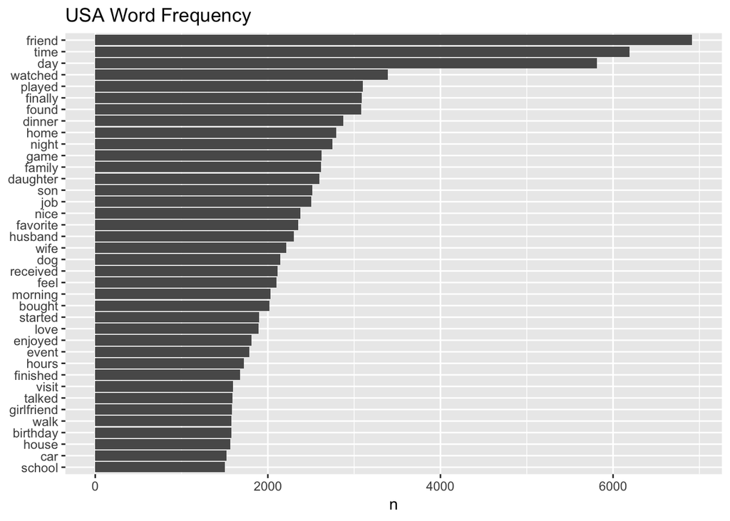

[interactive chart not shown]

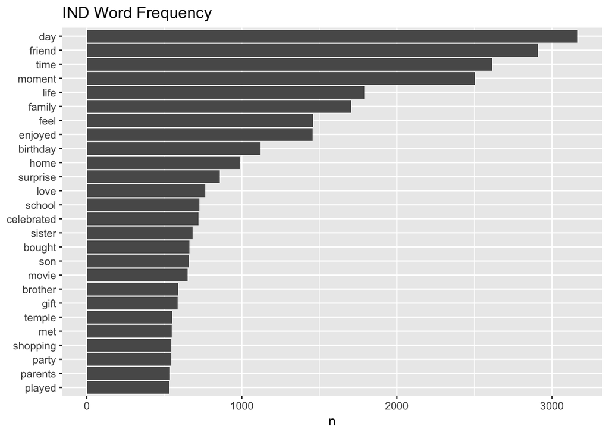

[interactive chart not shown]

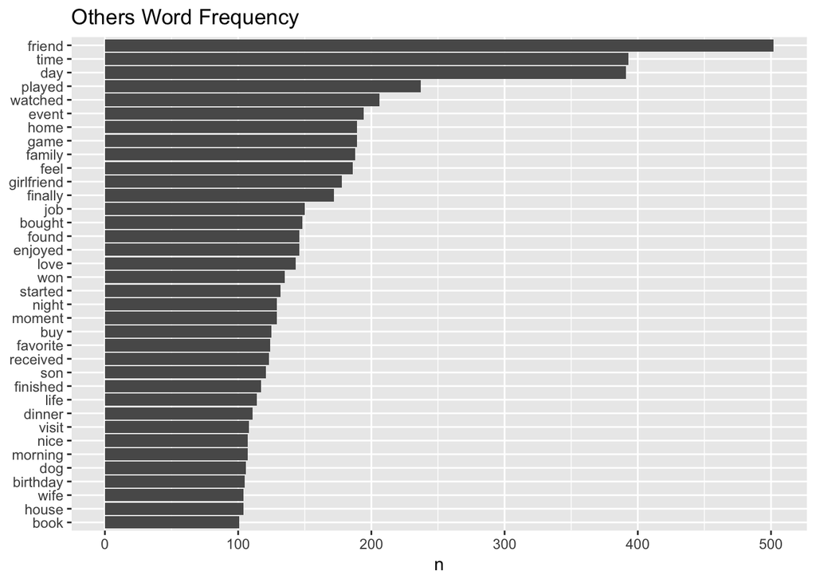

### Step.4 Words Sentiment Analysis

I created NRC word setiments histogram for each country group, and I compared the sentiments distributions among three groups. I found the sentiments distributions for 3 groups are relatively simillar. But “positive” is higher than “negative” in IND and OTHERS, “positive” is a little bit lower than “negative” in USA.

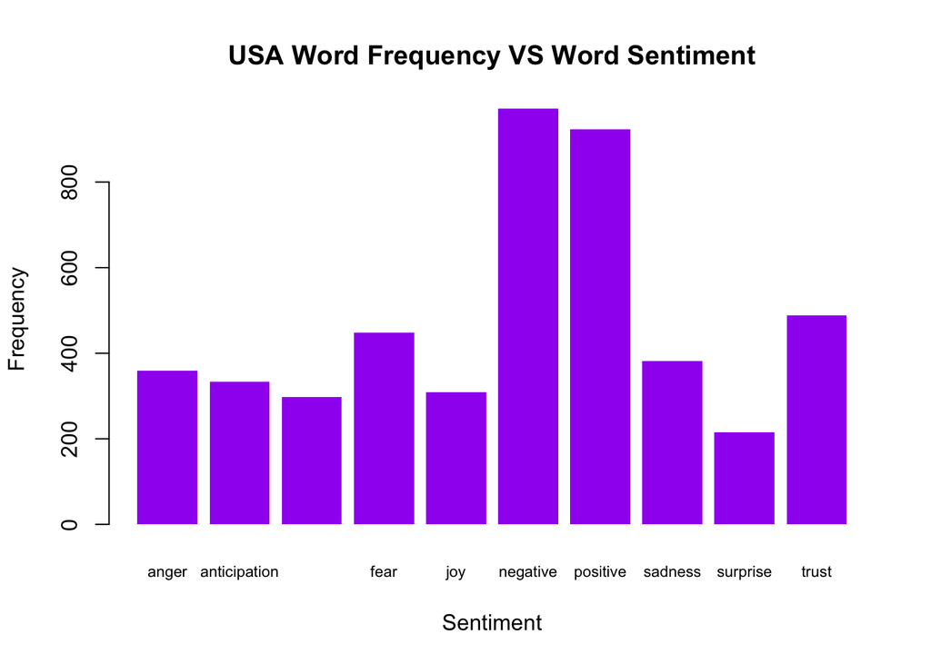

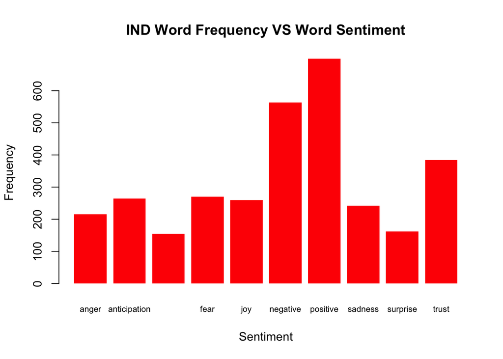

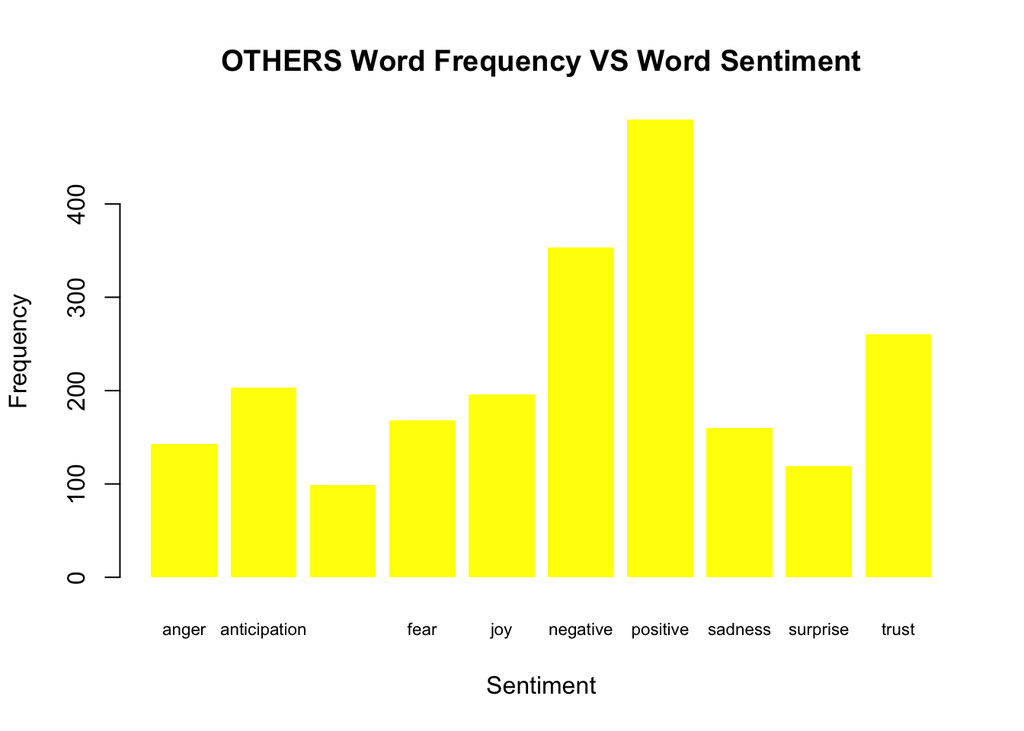

I am interested in “Most common positive and negative words” in Happy Moments for USA group. So I used “bing” to show the “Most common positive and negative words”for USA group. Finally, I get the top ten most common negative sentiment words are “hard”, “lost”, “funny”, “hang”, “break”, “unexpected”, “bad”, “stress”, “sick”, “issues”. The top ten most common positive sentiment words are “nice”, “favorite”, “love”, “enjoyed”, “won”, “fun”, “happiness”, “excited”, “free”, “helped”.

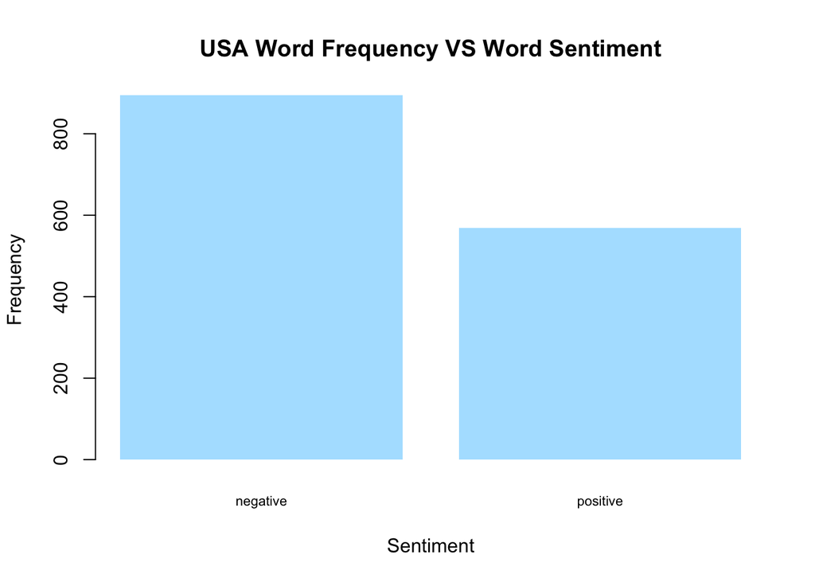

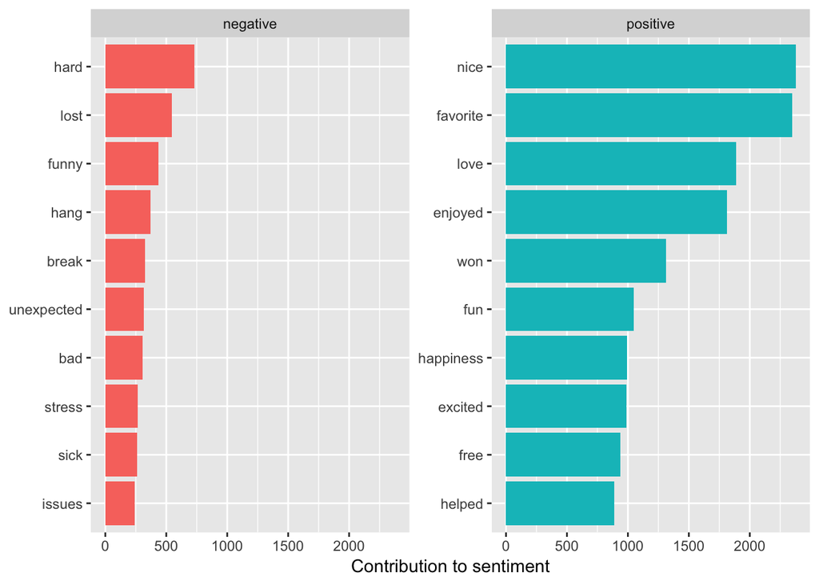

### Step.5 Test “Happiness U-Curve” theory

Previsouly, I read an essay about Happiness U-Curve with age. The Happiness U-Curve indicates that “Happiness declines with age for about two decades from early adulthood up until roughly the middle-age years, and then turns upward and increases with age.” I want to use three country group to test this theory. Firstly, I split each country group into 4 different age groups: under20;between20and35; between35and50 and 50above. Then, in each country group, I summed the word frequency for each age groups, then plot. Finally, I found in these three country groups, none of them followed the U-Curve. Thus, if I want to prove this theory, we need more data to analyze.

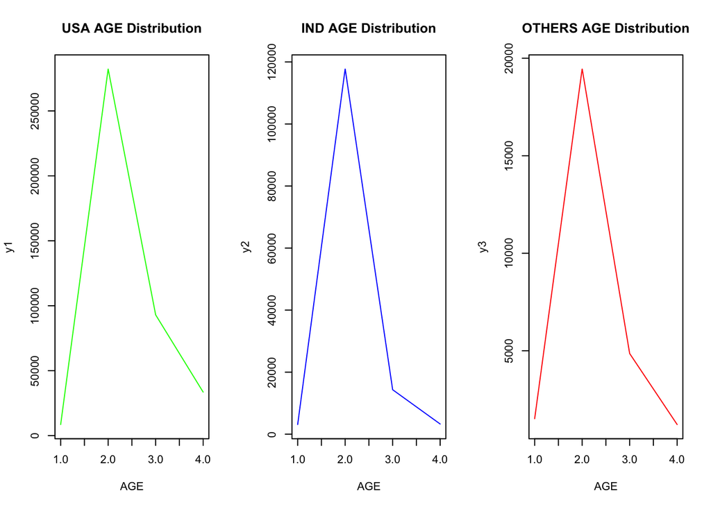

### Step.6 Topic Modeling

I did basic topic modeling for the 3 country groups. Firstly, I created a Document-Term matrix to format the files to enable analysis of the term. After generating the Document-Term matrix, I started LDA. I used LDA to identify “n”" topics (in this case I have chosen 7 topics as predicted_categories) through a process of iterative allocation of the documents to each topic.

Now I can review the Topics and Topic allocation, view the top 6 terms for each of the 7 topics

```
##      Topic 1    Topic 2   Topic 3   Topic 4    Topic 5     Topic 6
## [1,] "hours"    "event"   "friend"  "thesis"   "madurai"   "deployment"
## [2,] "surprise" "buy"     "time"    "cinema"   "cab"       "someones"
## [3,] "cat"      "managed" "day"     "german"   "character" "eagle"
## [4,] "people"   "book"    "watched" "thailand" "dorothy"   "hectic"
## [5,] "park"     "city"    "played"  "tablet"   "butterfly" "pay"
## [6,] "hard"     "won"     "finally" "sorority" "cashback"  "stepson"
##      Topic 7
## [1,] "day"
## [2,] "moment"
## [3,] "friend"
## [4,] "time"
## [5,] "life"
## [6,] "family"
```

Then I checked the per-document-per-word probability for each group. For example, on the first row, I can see that the probability of a word generating from Topic 1 in USA group is 0.177980543293706. On the fifth row, the probability of a word generating from Topic 2 in IND group is 0.100179540688083.

|  | document | topic | gamma |
| --- | --- | --- | --- |
| 1 | USA | 1 | 0.177980543293706 |
| 2 | IND | 1 | 0.00198275368578818 |
| 3 | OTHERS | 1 | 0.10842155125155 |
| 4 | USA | 2 | 0.0618797342818308 |
| 5 | IND | 2 | 0.100179540688083 |
| 6 | OTHERS | 2 | 0.15882950922629 |
| 7 | USA | 3 | 0.741553522152205 |
| 8 | IND | 3 | 0.198041185072623 |
| 9 | OTHERS | 3 | 0.605683203201925 |
| 10 | USA | 4 | 0.00528753082898454 |

[output cut: 11 more lines]

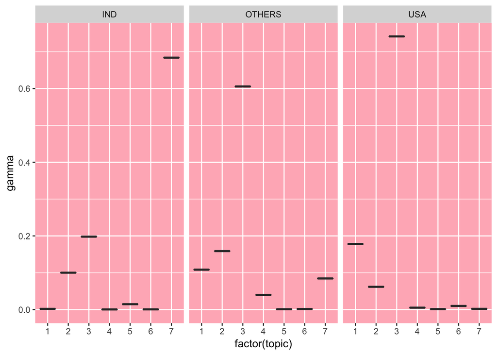